# Mathematical expression in R plots

Hao Wu

6/18/2020

### Introduction

R has powerful graphical capability even in the R base graphics. Here I’ll give a brief tutorial for including mathematical expression in the figures. More details can be found in the help for `plotmath`, but it is difficult to read and comprehend, especially for beginners. I encourage you to take a look at the example and demo for `plotmath` first, then read the following.

```r
demo(plotmath)
example(plotmath)
```

I assume - you have good understanding for most basic R plotting functions, such as `plot`, `text`, etc. - you know the Latex ways to math expressions and symbols.

The focus on this document is to add math equations to the plot.

### Quick start

The math formula in R plot needs to be wrapped in an object of `expression`. You can take a look at the help pages for `expression`, but when it is used in plot, it means to be rendered as a math formula instead of being evaluated.

Here, I’ll first create an empty figure, and then use the `text` function to  
write a simple expression in the figure.

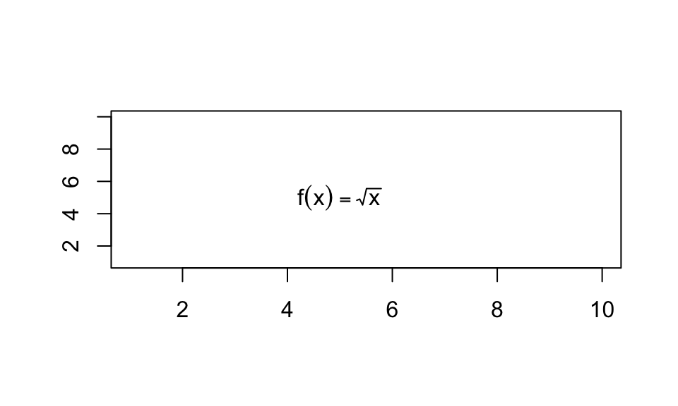

```r
plot(1:10, 1:10, xlab="", ylab="", type="n")
text(5, 5, expression(f(x)==sqrt(x)))
```

A few commments on this simple example:

- The `text` function usually takes a string for the text. Here I give it an `expression`, which will be shown as a math formula in the figure.
- It’s important to note that the the content inside `expression` isn’t within quote marks. If you put a quote marks in the expression, it’ll become a string. You can try the following to see what you get:

  ```r
  plot(1:10, 1:10, xlab="", ylab="", type="n")
  text(5, 5, expression("f(x)==sqrt(x)"))
  ```

- You perhaps noticed that I use things like `sqrt` and `==` in the expression, but they show as math symbols. These are the syntax R uses to render math expressions. You can get all these syntax in the help for `plotmath`.

### Use expressions in axis labels and figure titles

Similar to the `text` example above, you can use the `expression` in axis labels (`xlab` and `ylab` parameters) and figure titles (`main` parameter): Again, these parameters in the `plot` function usually takes strings. When you give them expressions, they will be shown as math formulas.

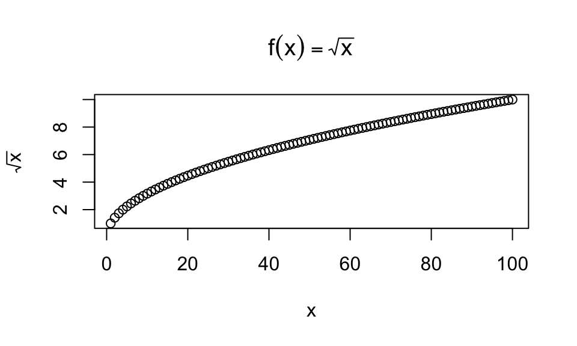

```r
x = 1:100
y = sqrt(x)
plot(x, y, xlab="x", ylab=expression(sqrt(x)), main=expression(f(x)==sqrt(x)) )
```

### Make it a little more complicated

Of course, the math formula can be complex, and include Greek letters. This requires you to be familiar with the Latex syntax. For all possible symbols, look at `demo(plotmath)`. The example below, I write the standard normal density function in a figure:

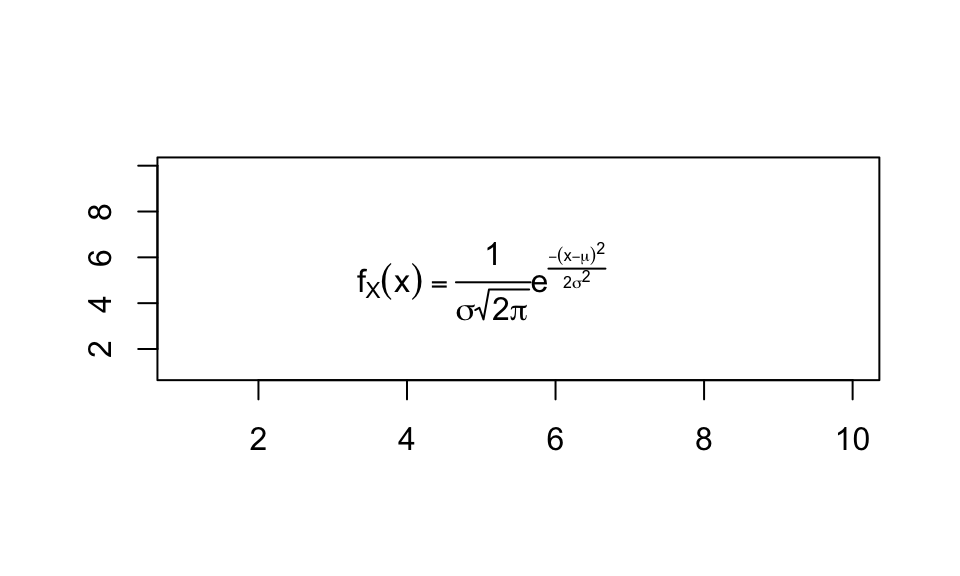

```r
plot(1:10, 1:10, xlab="", ylab="", type="n")
text(5, 5, expression(f[X](x)==frac(1, sigma*sqrt(2*pi))*plain(e)^{frac(-(x-mu)^2, 2*sigma^2)}))
```

- Take a careful look at the expression I used and make sure you understand all the parts.
- Note, the expression, albeit based on Latex, has some differences. For example, the subscript in Latex is achieved by underscore, i.e., `f_X` is shown as $f_X$ in latex. But in R, since the underscore is a reserved symbol, you must use `f[X]` in the expression to display $f_X$.

### Use `expression` with `paste`

Sometimes, you want to mix math expressions with simple text. For that, you have to use `paste` function to put the expression and text together.

Here is a simple example:

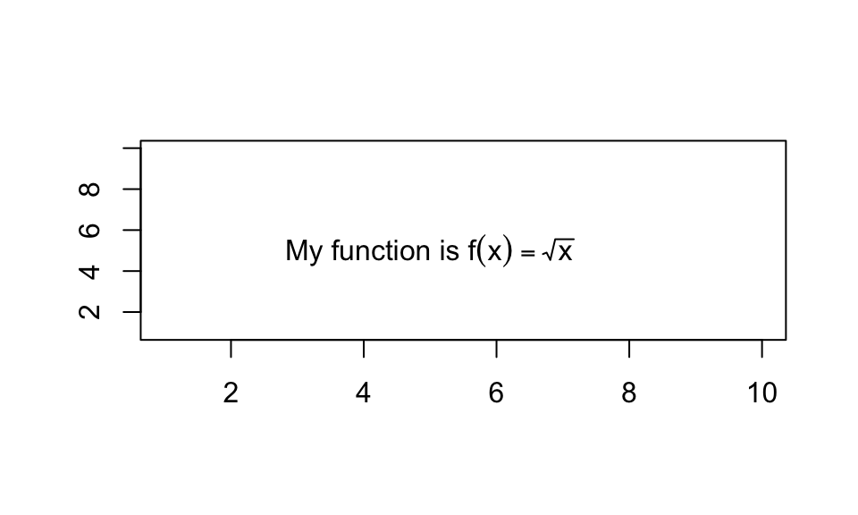

```r
plot(1:10, 1:10, xlab="", ylab="", type="n")
text(5, 5, expression(paste("My function is ", f(x)==sqrt(x))) )
```

A few notes:

- You must use `expression` outside of `paste`, so that the things pasted together will be evaluated as an expression. If you reverse the order, the figure will be messed up. Try following:

  ```r
  plot(1:10, 1:10, xlab="", ylab="", type="n")
  text(5, 5, paste(expression("My function is ", f(x)==sqrt(x))) )
  ```

- `paste` is usually used for concatenating strings together, but here it takes a string and an expression.
- If you want to have some R reserved special characters in the expression, for exampe, semi-colon, underscore, even space, you have to `paste` them in. For example, if you want to display a formula $f(x;k) = x^k$, you cannot do the following (you can try, it’ll give you an error).

  ```r
  plot(1:10, 1:10, xlab="", ylab="", type="n")
  text(5, 5, expression(f(x;k) = x^k) )
  ```

  You’ll need to `paste` the semi-colon in:

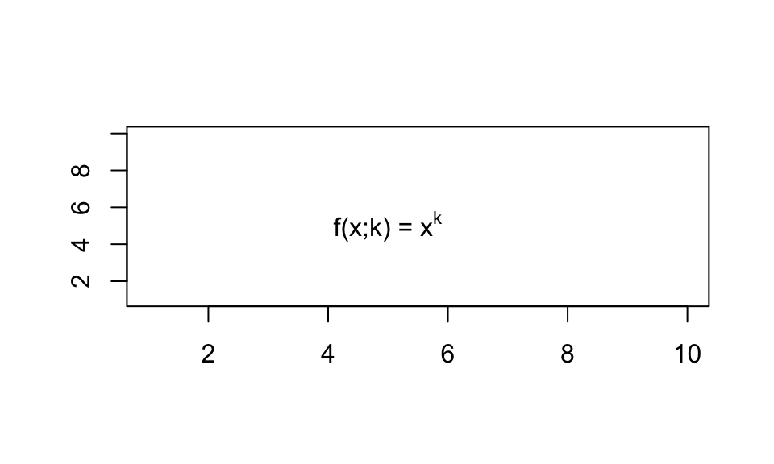

  ```r
  plot(1:10, 1:10, xlab="", ylab="", type="n")
  text(5, 5, expression(paste("f(x;k) = ", x^k)))
  ```

A more complicated example. If you want to display $f(x; \sigma) = x^\sigma$, Since the greek letter $\sigma$ need to be typed in as `sigma` in the expression, you need to paste several components together.

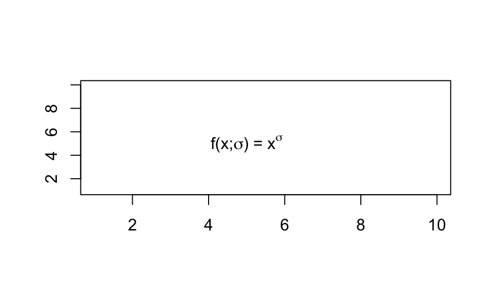

```r
plot(1:10, 1:10, xlab="", ylab="", type="n")
text(5, 5, expression(paste("f(x;", sigma, ") = ", x^sigma)))
```

In the above expression, I pasted 4 parts together:

- `"f(x;"` as a string
- `sigma` as an expression
- `") = "` as a string
- x^sigma as an expression